# CompressNet_usage

# Usage of Netty function

Watching the usage of the package with **Netty**, the function that import a data frame as example. Obtaining two complete network (the second one with modified settings)

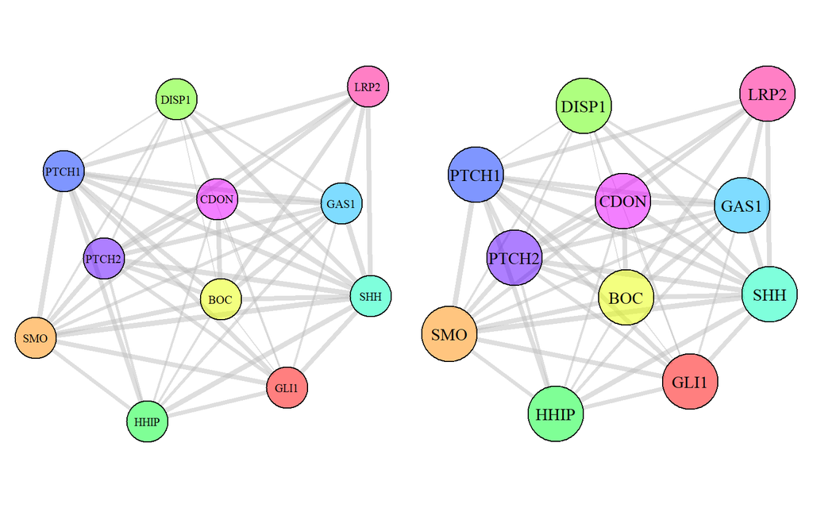

```r
library(CompressNet)

df = Netty()
par(mfrow = c(1, 2))
Network = draw_complete_net(df, nodeA = "preferredName_A", nodeB = "preferredName_B", score = "score")
Network2 = draw_complete_net(df, nodeA = "preferredName_A", nodeB = "preferredName_B", score = "score",fontSize = 1, opacity = 0.5, size = 35)
```

In addition to the networks reported above, the **draw_complete_network** function also allows you to obtain:

### **nodes**

Returns the nodes that compose the network, so the participants of the interaction.

```r
Network$nodes
```

```
#>     name
#> 1   GLI1
#> 2    SMO
#> 3    BOC
#> 4  DISP1
#> 5   HHIP
#> 6    SHH
#> 7   GAS1
#> 8  PTCH1
#> 9  PTCH2
#> 10  CDON
#> 11  LRP2
```

### **edges_data**

Returns the data frame that describe the network, so report the nodes and the score of interactions. Furthermore, this element is very important because it is used in most compression functions

```r
Network$edges_data
```

```
#>    preferredName_A preferredName_B score
#> 1             GLI1           DISP1 0.413
#> 2             GLI1             BOC 0.481
#> 3             GLI1            CDON 0.552
#> 4             GLI1            GAS1 0.586
#> 5             GLI1           PTCH2 0.842
#> 6             GLI1            HHIP 0.898
#> 7             GLI1           PTCH1 0.978
#> 8             GLI1             SHH 0.979
#> 9             GLI1             SMO 0.988
#> 10             SMO           DISP1 0.598
#> 11             SMO            GAS1 0.758
#> 12             SMO            CDON 0.798
#> 13             SMO            HHIP 0.848
#> 14             SMO             BOC 0.963
```

[output cut: 36 more lines]

### **Complete_network**

Returns the igraph object, this is useful when I use, in future, the compression functions. In fact, we will see, inside these functions we recall this object.

```r
Network$Complete_network
```

```
#> IGRAPH a0b7f7e UN-- 11 50 --
#> + attr: name (v/c), color (v/c), size (v/n), label.cex (v/n), score
#> | (e/n), width (e/n), color (e/c)
#> + edges from a0b7f7e (vertex names):
#>  [1] GLI1 --DISP1 GLI1 --BOC   GLI1 --CDON  GLI1 --GAS1  GLI1 --PTCH2
#>  [6] GLI1 --HHIP  GLI1 --PTCH1 GLI1 --SHH   GLI1 --SMO   SMO  --DISP1
#> [11] SMO  --GAS1  SMO  --CDON  SMO  --HHIP  SMO  --BOC   SMO  --PTCH2
#> [16] SMO  --SHH   SMO  --PTCH1 BOC  --DISP1 BOC  --HHIP  BOC  --LRP2
#> [21] BOC  --CDON  BOC  --PTCH2 BOC  --GAS1  BOC  --PTCH1 BOC  --SHH
#> [26] DISP1--PTCH1 DISP1--PTCH2 DISP1--CDON  DISP1--GAS1  DISP1--SHH
#> [31] HHIP --CDON  HHIP --PTCH2 HHIP --GAS1  HHIP --PTCH1 HHIP --SHH
#> + ... omitted several edges
```

### **edges**

Returns the dataframe of edges_data modified, in this case is a kable object (a graphically nicer structure)

## Compression

Using the **GraphCompression** function we can reduce the size of the network by filtering the network based on a value. As we can see, within the function we recall the two elements that we previously defined as important.

### **degree**

Here, the compression with the degree centrality Are reported two examples, because we can modify the top value (the value that is used to filter the network). As we can see the network change.

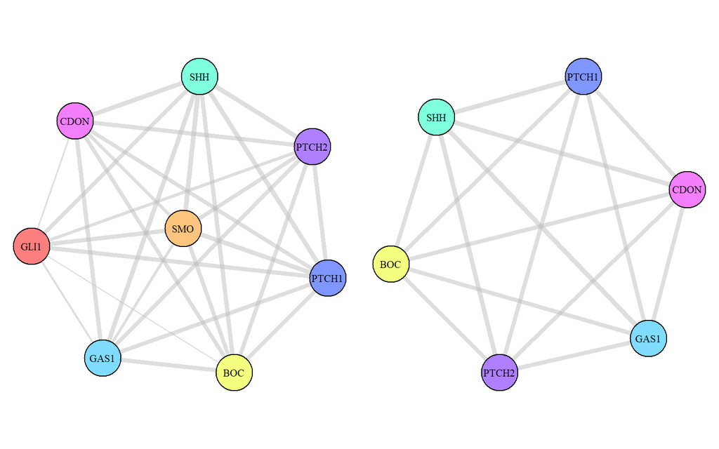

```r
par(mfrow = c(1, 2))
comp1 = GraphCompression(Network = Network$Complete_network, links = Network$edges_data, method = "degree")
comp1b = GraphCompression(Network = Network$Complete_network, links = Network$edges_data, method = "degree", top = 0.3)
```

**This top value can be changed also in the other compression functions to obtain the desired results.**

### **betweenness**

Here, the compression with the betweenness centrality

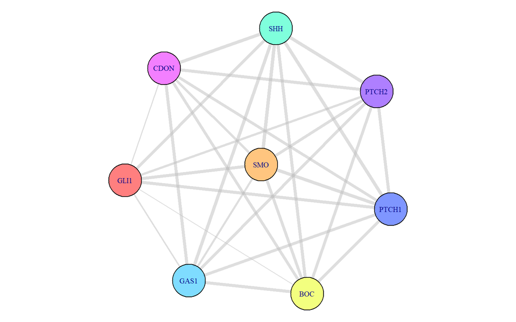

```r
comp2 = GraphCompression(Network = Network$Complete_network, links = Network$edges_data, method = "betweenness")
```

### **closeness**

Here, the compression with the closeness centrality

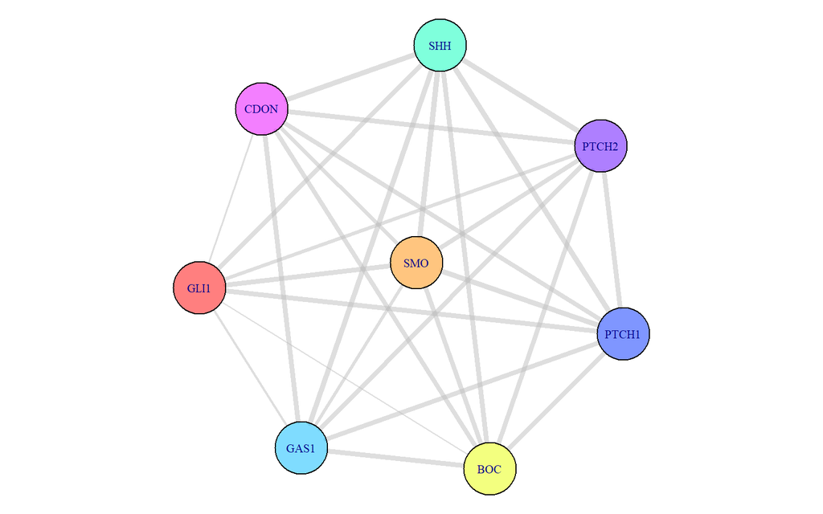

```r
comp3 = GraphCompression(Network = Network$Complete_network, links = Network$edges_data, method = "closeness")
```

### **eigen**

Here, the compression with the eigen vector centrality

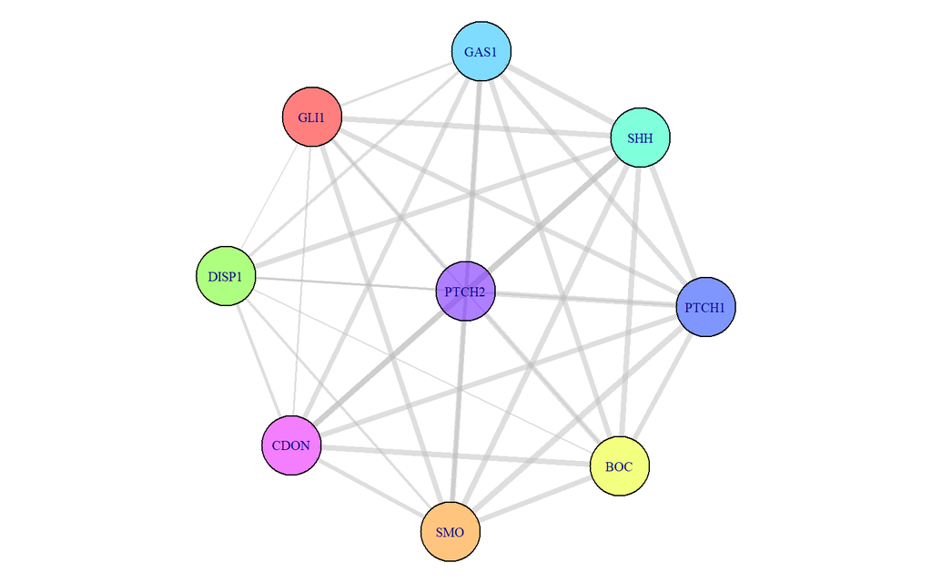

```r
comp4 = GraphCompression(Network = Network$Complete_network, links = Network$edges_data, method = "eigen")
```

### **pagerank**

Here, the compression with the pagerank centrality

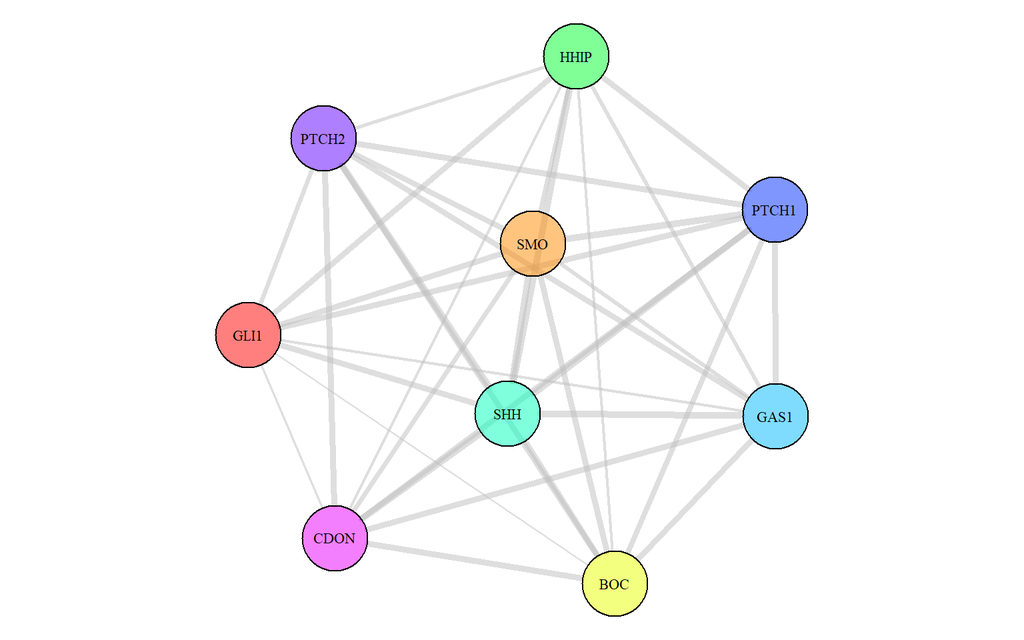

```r
comp5 = GraphCompression(Network = Network$Complete_network, links = Network$edges_data, method = "pagerank")
```

## Other outputs of GraphCompression

Here, are reported all the other output of the **GraphCompression** function (referring only to the first example with degree method)

### **filters_data**

Returns a data frame with the filters, used to reduce the network

```r
comp1$filters_data
```

```
#>         Threshold Top
#> Filters         8 0.9
```

### **edges_data**

Returns a data frame with all the information (nodes and scores) about the compressed graph. (It is useful when we want to further compress the already compressed network)

```r
comp1$edges_data
```

```
#>    preferredName_A preferredName_B score
#> 2             GLI1             BOC 0.481
#> 3             GLI1            CDON 0.552
#> 4             GLI1            GAS1 0.586
#> 5             GLI1           PTCH2 0.842
#> 7             GLI1           PTCH1 0.978
#> 8             GLI1             SHH 0.979
#> 9             GLI1             SMO 0.988
#> 11             SMO            GAS1 0.758
#> 12             SMO            CDON 0.798
#> 14             SMO             BOC 0.963
#> 15             SMO           PTCH2 0.993
#> 16             SMO             SHH 0.999
#> 17             SMO           PTCH1 0.999
#> 21             BOC            CDON 0.942
#> 22             BOC           PTCH2 0.974
#> 23             BOC            GAS1 0.982
#> 24             BOC           PTCH1 0.993
#> 25             BOC             SHH 0.996
#> 37             SHH            GAS1 0.999
#> 38             SHH           PTCH1 0.999
#> 39             SHH            CDON 0.999
#> 40             SHH           PTCH2 0.999
#> 42            GAS1           PTCH2 0.955
#> 43            GAS1            CDON 0.995
#> 44            GAS1           PTCH1 0.998
#> 45           PTCH1           PTCH2 0.928
#> 47           PTCH1            CDON 0.998
#> 49           PTCH2            CDON 0.968
```

### **values**

Returns a table (kable object) with the value (degree, betweenness, closeness, eigen, pagerank) for all nodes and we also see which node passes the filter and which does not.

```r
comp1$values
```

|  | x |
| --- | --- |
| GLI1 | 9 |
| SMO | 9 |
| BOC | 10 |
| DISP1 | 8 |
| HHIP | 8 |
| SHH | 10 |
| GAS1 | 10 |
| PTCH1 | 10 |
| PTCH2 | 10 |
| CDON | 10 |
| LRP2 | 6 |

### **sub_graph**

Returns the igraph object of the network. (It is useful when we want to further compress the already compressed network)

```r
comp1$sub_graph
```

```
#> IGRAPH a1250a1 UN-- 8 28 --
#> + attr: name (v/c), color (v/c), size (v/n), label.cex (v/n), score
#> | (e/n), width (e/n), color (e/c)
#> + edges from a1250a1 (vertex names):
#>  [1] GLI1 --BOC   GLI1 --CDON  GLI1 --GAS1  GLI1 --PTCH2 GLI1 --PTCH1
#>  [6] GLI1 --SHH   GLI1 --SMO   SMO  --GAS1  SMO  --CDON  SMO  --BOC
#> [11] SMO  --PTCH2 SMO  --SHH   SMO  --PTCH1 BOC  --CDON  BOC  --PTCH2
#> [16] BOC  --GAS1  BOC  --PTCH1 BOC  --SHH   SHH  --GAS1  SHH  --PTCH1
#> [21] SHH  --CDON  SHH  --PTCH2 GAS1 --PTCH2 GAS1 --CDON  GAS1 --PTCH1
#> [26] PTCH1--PTCH2 PTCH1--CDON  PTCH2--CDON
```

### **edges**

Returns the kable object with all the information (nodes and scores) about the compressed graph.

```r
comp1$edges
```

|  | preferredName_A | preferredName_B | score |
| --- | --- | --- | --- |
| 2 | GLI1 | BOC | 0.481 |
| 3 | GLI1 | CDON | 0.552 |
| 4 | GLI1 | GAS1 | 0.586 |
| 5 | GLI1 | PTCH2 | 0.842 |
| 7 | GLI1 | PTCH1 | 0.978 |
| 8 | GLI1 | SHH | 0.979 |
| 9 | GLI1 | SMO | 0.988 |
| 11 | SMO | GAS1 | 0.758 |
| 12 | SMO | CDON | 0.798 |
| 14 | SMO | BOC | 0.963 |
| 15 | SMO | PTCH2 | 0.993 |
| 16 | SMO | SHH | 0.999 |
| 17 | SMO | PTCH1 | 0.999 |
| 21 | BOC | CDON | 0.942 |
| 22 | BOC | PTCH2 | 0.974 |
| 23 | BOC | GAS1 | 0.982 |
| 24 | BOC | PTCH1 | 0.993 |
| 25 | BOC | SHH | 0.996 |
| 37 | SHH | GAS1 | 0.999 |
| 38 | SHH | PTCH1 | 0.999 |
| 39 | SHH | CDON | 0.999 |
| 40 | SHH | PTCH2 | 0.999 |
| 42 | GAS1 | PTCH2 | 0.955 |
| 43 | GAS1 | CDON | 0.995 |
| 44 | GAS1 | PTCH1 | 0.998 |
| 45 | PTCH1 | PTCH2 | 0.928 |
| 47 | PTCH1 | CDON | 0.998 |
| 49 | PTCH2 | CDON | 0.968 |

## Clustering

### **kmeans**

Here, the compression method is based on the kmeans clustering. Are reported two examples, where the second one has a change in the number of clusters.

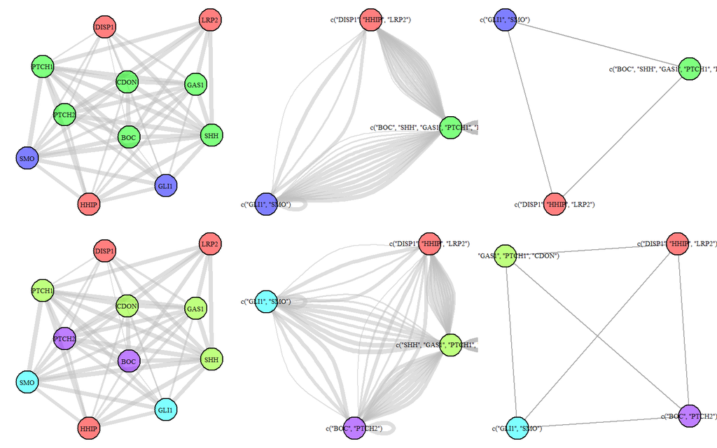

```r
par(mfrow = c(2, 3))
comp6 = GraphCompression(Network = Network$Complete_network, method = "kmeans")
comp6b = GraphCompression(Network = Network$Complete_network, method = "kmeans", num_cluster = 4)
```

### **dbscan**

In this case the compression method is based on dbscan clustering. Two examples are shown, where in the second the eps value has been changed.

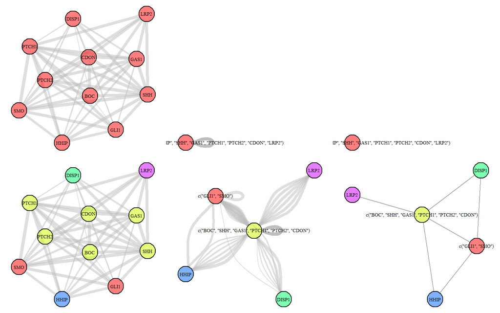

```r
par(mfrow = c(2, 3))
comp7 = GraphCompression(Network = Network$Complete_network, method = "dbscan")
comp7b = GraphCompression(Network = Network$Complete_network, method = "dbscan", eps = 0.6)
```

## Other outputs of GraphCompression (kmeans method)

### **info**

Returns the information about the composition of the cluster

```r
comp6$info
```

```
#>       V1    colors
#> GLI1   3 #0000FF80
#> SMO    3 #0000FF80
#> BOC    2 #00FF0080
#> DISP1  1 #FF000080
#> HHIP   1 #FF000080
#> SHH    2 #00FF0080
#> GAS1   2 #00FF0080
#> PTCH1  2 #00FF0080
#> PTCH2  2 #00FF0080
#> CDON   2 #00FF0080
#> LRP2   1 #FF000080
```

### **relationship**

Returns a matrix that describe/represent the relationship/interaction between nodes

```r
comp6$relationship
```

```
#> 11 x 11 sparse Matrix of class "dgCMatrix"
#>   [[ suppressing 11 column names 'GLI1', 'SMO', 'BOC' ... ]]
#>
#> GLI1  . 1 1 1 1 1 1 1 1 1 .
#> SMO   1 . 1 1 1 1 1 1 1 1 .
#> BOC   1 1 . 1 1 1 1 1 1 1 1
#> DISP1 1 1 1 . . 1 1 1 1 1 .
#> HHIP  1 1 1 . . 1 1 1 1 1 .
#> SHH   1 1 1 1 1 . 1 1 1 1 1
#> GAS1  1 1 1 1 1 1 . 1 1 1 1
#> PTCH1 1 1 1 1 1 1 1 . 1 1 1
#> PTCH2 1 1 1 1 1 1 1 1 . 1 1
#> CDON  1 1 1 1 1 1 1 1 1 . 1
#> LRP2  . . 1 . . 1 1 1 1 1 .
```

### **cluster**

Returns the cluster of the compressed network

```r
comp6$cluster
```

```
#> [[1]]
#> [1] "DISP1" "HHIP"  "LRP2"
#>
#> [[2]]
#> [1] "BOC"   "SHH"   "GAS1"  "PTCH1" "PTCH2" "CDON"
#>
#> [[3]]
#> [1] "GLI1" "SMO"
```

### **sub_graph**

Returns the igraph object of the network (the simplified one). (It is useful when we want to further compress the already compressed network)

```r
comp6$sub_graph
```

```
#> IGRAPH a2fa64d UN-- 3 3 --
#> + attr: name (v/x)
#> + edges from a2fa64d (vertex names):
#> [1] DISP1, HHIP , LRP2 --BOC  , SHH  , GAS1 , PTCH1, PTCH2, CDON
#> [2] DISP1, HHIP , LRP2 --GLI1, SMO
#> [3] BOC  , SHH  , GAS1 , PTCH1, PTCH2, CDON --GLI1, SMO
```

## Other outputs of GraphCompression (dbscamn method)

### **cluster**

Returns the cluster composition of the network

```r
comp7$cluster
```

```
#> $`#FF000080`
#>  [1] "GLI1"  "SMO"   "BOC"   "DISP1" "HHIP"  "SHH"   "GAS1"  "PTCH1" "PTCH2"
#> [10] "CDON"  "LRP2"
```

### **info**

Returns the dbscan process settings and the results

```r
comp7$info
```

```
#> DBSCAN clustering for 11 objects.
#> Parameters: eps = 0.8, minPts = 1
#> Using euclidean distances and borderpoints = TRUE
#> The clustering contains 1 cluster(s) and 0 noise points.
#>
#>  1
#> 11
#>
#> Available fields: cluster, eps, minPts, metric, borderPoints
```

### **sub_graph**

Returns the igraph object of the network (the simplified one). (It is useful when we want to further compress the already compressed network)

```r
comp7$sub_graph
```

```
#> IGRAPH a3377d3 UN-- 1 0 --
#> + attr: name (v/x)
#> + edges from a3377d3 (vertex names):
```

## Compression of a compressed network (sub-sub-graph)

Here, is reported the compression of the sub_graph created with the degree method (example **comp1**). It is reported only one example as re-compression, but we can compress the sub_graph with all the method. (We can also continue to compress the sub-sub-graph obtaining a sub-sub-sub-graph)

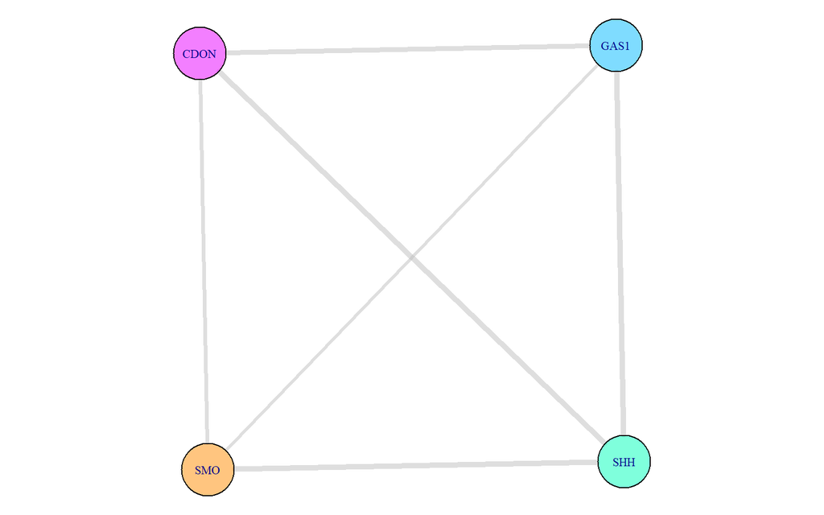

```r
comp1c = GraphCompression(comp1$sub_graph, comp1$edges_data, method = "eigen")
```

# Usage of the R package taking the data via API

```r
df2 = get_partners("TP53")
options(width = 200)
df2
```

```
#> # A tibble: 35 × 13
#>    stringId_A           stringId_B           preferredName_A preferredName_B ncbiTaxonId score nscore fscore pscore ascore escore dscore tscore
#>    <chr>                <chr>                <chr>           <chr>                 <dbl> <dbl>  <dbl>  <dbl>  <dbl>  <dbl>  <dbl>  <dbl>  <dbl>
#>  1 9606.ENSP00000212015 9606.ENSP00000254719 SIRT1           RPA1                   9606 0.412      0      0      0  0.089  0.317    0    0.13
#>  2 9606.ENSP00000212015 9606.ENSP00000258149 SIRT1           MDM2                   9606 0.699      0      0      0  0      0.292    0    0.592
#>  3 9606.ENSP00000212015 9606.ENSP00000262367 SIRT1           CREBBP                 9606 0.754      0      0      0  0.088  0.101    0    0.724
#>  4 9606.ENSP00000212015 9606.ENSP00000335153 SIRT1           HSP90AA1               9606 0.803      0      0      0  0.047  0.394    0    0.686
#>  5 9606.ENSP00000212015 9606.ENSP00000278616 SIRT1           ATM                    9606 0.856      0      0      0  0.049  0        0    0.855
#>  6 9606.ENSP00000212015 9606.ENSP00000263253 SIRT1           EP300                  9606 0.972      0      0      0  0.138  0.698    0    0.902
#>  7 9606.ENSP00000212015 9606.ENSP00000269305 SIRT1           TP53                   9606 0.999      0      0      0  0      0.886    0.9  0.99
#>  8 9606.ENSP00000254719 9606.ENSP00000263253 RPA1            EP300                  9606 0.466      0      0      0  0.047  0.133    0    0.406
#>  9 9606.ENSP00000254719 9606.ENSP00000278616 RPA1            ATM                    9606 0.928      0      0      0  0.047  0.66     0.5  0.611
#> 10 9606.ENSP00000254719 9606.ENSP00000269305 RPA1            TP53                   9606 0.999      0      0      0  0.117  0.982    0.4  0.932
#> # ℹ 25 more rows
```

Obtaining the complete network (left part) and one example of compression (right part):

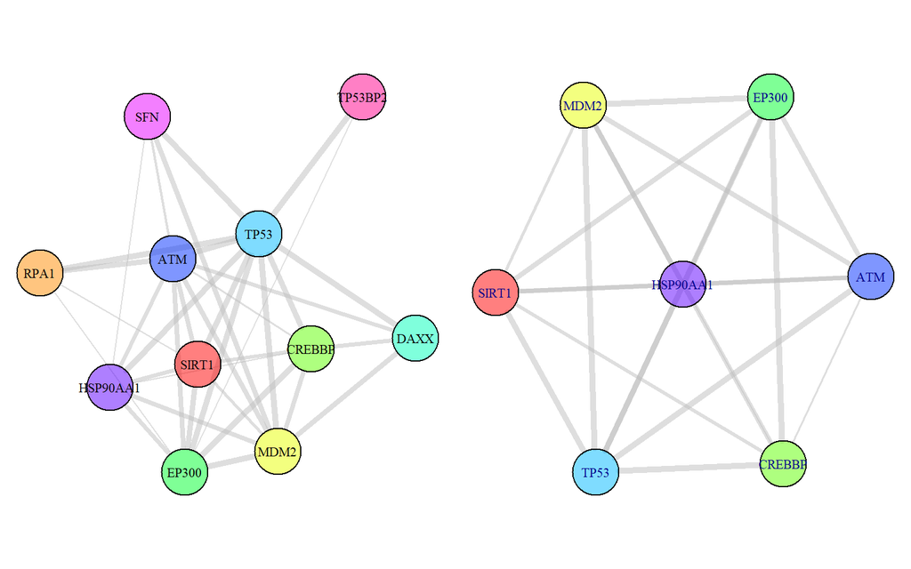

```r
par(mfrow = c(1, 2))
Net = draw_complete_net(df2, nodeA = "preferredName_A", nodeB = "preferredName_B", score = "score")
Comp8 = GraphCompression(Net$Complete_network, Net$edges_data, method = "closeness")
```

# Usage of the R package using an own data frame

Here we use this “strange” method to load the file because it is saved in **inst/extdata**, which is a folder where files external to the main package code are placed. This type of upload only applies in this case to the cartoon, normally just upload the file and read it.

```r
file_path = system.file("extdata", "Network_Data.csv", package = "CompressNet")
df3 = read.csv(file_path)
head(df3)
```

```
#>   Nodo_1 Nodo_2 Peso
#> 1      R      M    7
#> 2      F      X    2
#> 3      E      U    7
#> 4      U      L    5
#> 5      O      O    3
#> 6      Q      R    8
```

Obtaining the complete network (left part) and one example of compression (right part):

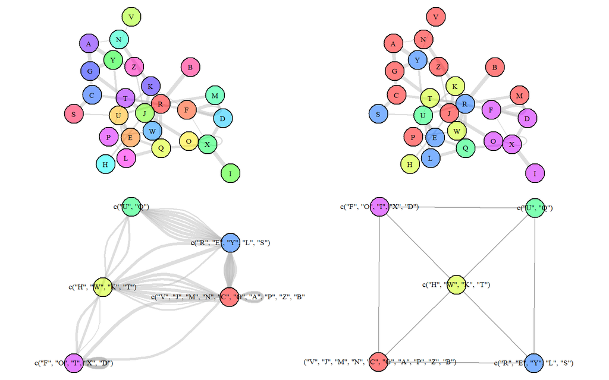

```r
par(mfrow = c(2, 2))
Net2 = draw_complete_net(df3, nodeA = "Nodo_1", nodeB = "Nodo_2", score = "Peso")
Comp9 = GraphCompression(Net2$Complete_network, method = "kmeans", num_cluster = 5)
```